# Practical 16 Optimization

Ndivhuwo Nyase

2023-02-13

## Question 1

```r
tobacco <- read.delim("~/Desktop/statistics-computing-R/datasets/tobacco.txt")
head(tobacco)
```

```
##   burn sugar nicotine nitrogen chlorine potas phospho calcium magnes
## 1 1.55 20.05     1.38     2.02     2.90  2.17    0.51    3.47   0.91
## 2 1.63 12.58     2.64     2.62     2.78  1.72    0.50    4.57   1.25
## 3 1.66 18.56     1.56     2.08     2.68  2.40    0.43    3.52   0.82
## 4 1.52 18.56     2.22     2.20     3.17  2.06    0.52    3.69   0.97
## 5 1.70 14.02     2.85     2.38     2.52  2.18    0.42    4.01   1.12
## 6 1.68 15.64     1.24     2.03     2.56  2.57    0.44    2.79   0.82
```

```r
summary(tobacco)
```

```
##       burn           sugar          nicotine        nitrogen
##  Min.   :1.400   Min.   :12.58   Min.   :1.240   Min.   :1.720
##  1st Qu.:1.550   1st Qu.:14.79   1st Qu.:1.870   1st Qu.:1.980
##  Median :1.680   Median :17.42   Median :2.160   Median :2.080
##  Mean   :1.688   Mean   :16.70   Mean   :2.159   Mean   :2.157
##  3rd Qu.:1.780   3rd Qu.:18.56   3rd Qu.:2.430   3rd Qu.:2.210
##  Max.   :2.090   Max.   :20.05   Max.   :3.280   Max.   :2.870
##     chlorine         potas          phospho          calcium
##  Min.   :0.740   Min.   :1.640   Min.   :0.4000   Min.   :2.790
##  1st Qu.:2.150   1st Qu.:2.150   1st Qu.:0.4800   1st Qu.:3.310
##  Median :2.670   Median :2.220   Median :0.5000   Median :3.560
##  Mean   :2.481   Mean   :2.238   Mean   :0.4868   Mean   :3.592
##  3rd Qu.:2.840   3rd Qu.:2.400   3rd Qu.:0.5100   3rd Qu.:3.720
##  Max.   :3.300   Max.   :2.640   Max.   :0.5600   Max.   :4.570
##      magnes
##  Min.   :0.780
##  1st Qu.:0.860
##  Median :0.950
##  Mean   :0.964
##  3rd Qu.:1.040
##  Max.   :1.250
```

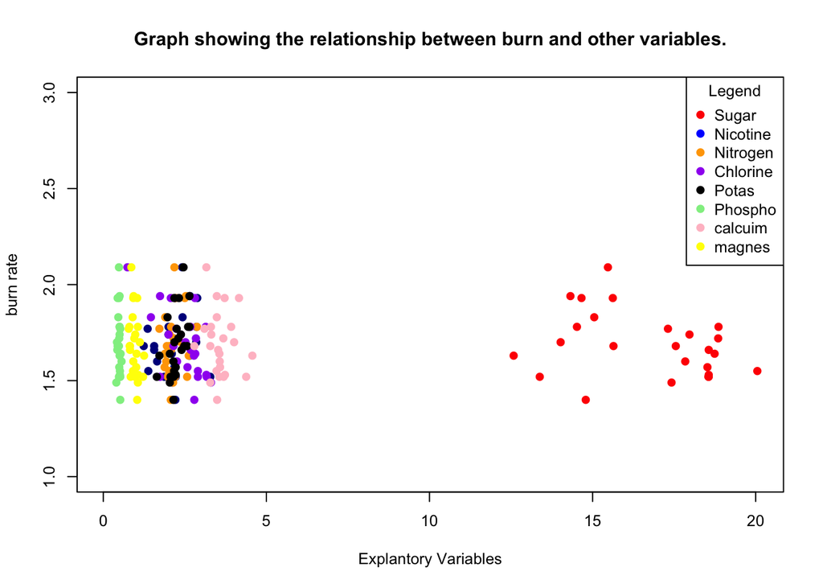

```r
par(cex = 0.8)
plot(x= 0,
     xlab = 'Explantory Variables',
     ylab = 'burn rate',
     main = 'Graph showing the relationship between burn and other variables.',
     pch=19,type = 'b', xlim = c(0,max(tobacco$sugar)), ylim = c(1,3))

# Adding scatterplot of sugar
points(tobacco$sugar, y =tobacco$burn, col='red', pch=19)

# Adding scatterplot of nicotine
points(tobacco$nicotine, y= tobacco$burn ,col='darkblue', pch=19)

# Adding scatterplot of nitrogen
points(tobacco$nitrogen,y =tobacco$burn, col='orange', pch=19)

# Adding scatterplot of chlorine
points(tobacco$chlorine,y =tobacco$burn, col='purple', pch=19)

# Adding scatterplot of potas
points(tobacco$potas,y =tobacco$burn, col='black', pch=19)

# phospho
points(tobacco$phospho,y =tobacco$burn, col='lightgreen', pch=19)

# Adding scatterplot of calcuim
points(tobacco$calcium,y =tobacco$burn, col='pink', pch=19)

points(tobacco$magnes,y =tobacco$burn, col = 'yellow', pch = 19)

legend('topright',legend=c('Sugar','Nicotine','Nitrogen',
                          'Chlorine','Potas', 'Phospho', 'calcuim', 'magnes'), pch=c(19, 19),
       col=c('red','blue','orange','purple','black', 'lightgreen', 'pink', 'yellow'), title = 'Legend')
```

```r
burn_corr <- cor(tobacco$burn,tobacco)
burn_corr
```

```
##      burn      sugar nicotine  nitrogen   chlorine     potas    phospho
## [1,]    1 -0.3049965 0.208769 0.2260002 -0.6234392 0.4865503 -0.1752969
##         calcium     magnes
## [1,] -0.1212625 -0.3134037
```

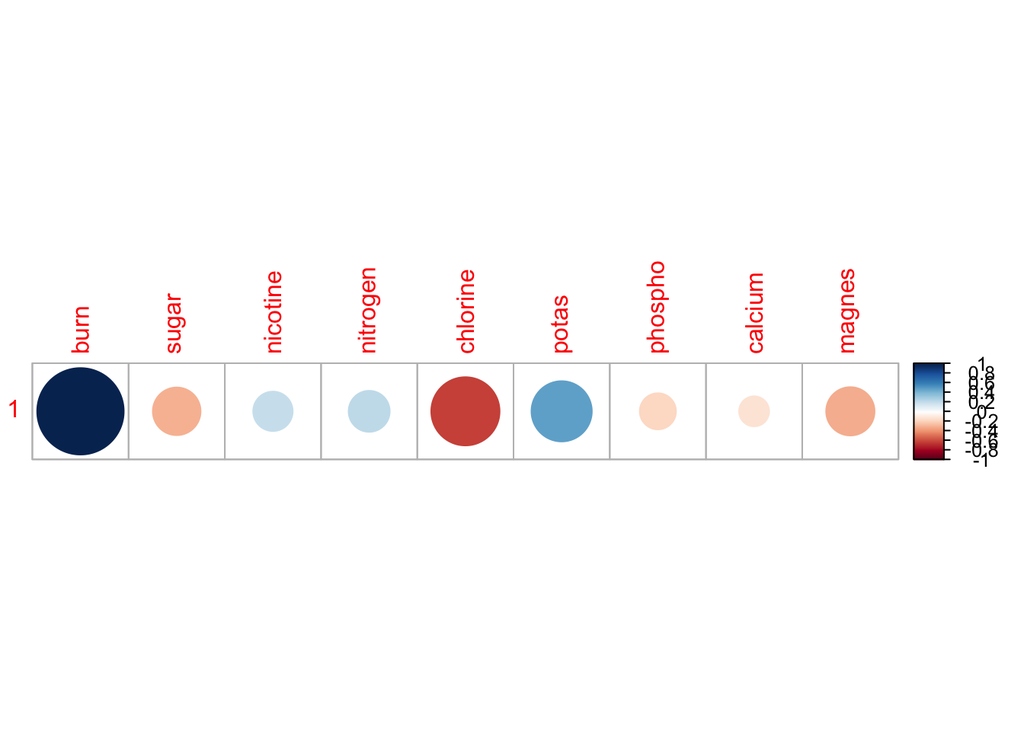

```r
corrplot(burn_corr)
```

The correlation suggests there is a strong relationship with potasium and chlorine.

- burn rate and % *chlorine: -0.6234392*
- burn rate and % *potassium: 0.4865503*

## Question 1b

#Fit a simple linear regression model using lm() and print the model output. Choose the most pertinent explanatory variable to model the response variable, providing a motivation for your choice from the output in (a).

```r
model1b <- lm(burn ~ sugar + chlorine + nicotine + potas + nitrogen + calcium + phospho + magnes,data = tobacco)
summary(model1b)
```

```
##
## Call:
## lm(formula = burn ~ sugar + chlorine + nicotine + potas + nitrogen +
##     calcium + phospho + magnes, data = tobacco)
##
## Residuals:
##       Min        1Q    Median        3Q       Max
## -0.149403 -0.048228  0.001326  0.047505  0.137921
##
## Coefficients:
##              Estimate Std. Error t value Pr(>|t|)
## (Intercept)  1.563675   0.712327   2.195   0.0432 *
## sugar       -0.004242   0.019449  -0.218   0.8301
## chlorine    -0.134570   0.056919  -2.364   0.0310 *
## nicotine     0.091315   0.095146   0.960   0.3515
## potas        0.305924   0.168749   1.813   0.0887 .
## nitrogen    -0.032790   0.191465  -0.171   0.8662
## calcium      0.179185   0.119419   1.500   0.1530
## phospho     -0.623569   0.647028  -0.964   0.3495
## magnes      -0.645189   0.404667  -1.594   0.1304
## ---
## Signif. codes:  0 '***' 0.001 '**' 0.01 '*' 0.05 '.' 0.1 ' ' 1
##
## Residual standard error: 0.1077 on 16 degrees of freedom
## Multiple R-squared:  0.7226, Adjusted R-squared:  0.5838
## F-statistic: 5.209 on 8 and 16 DF,  p-value: 0.002488
```

```r
model_burn_chl <- lm(burn ~ chlorine,data = tobacco)
summary(model_burn_chl)
```

```
##
## Call:
## lm(formula = burn ~ chlorine, data = tobacco)
##
## Residuals:
##       Min        1Q    Median        3Q       Max
## -0.295267 -0.064830 -0.006598  0.093709  0.298555
##
## Coefficients:
##             Estimate Std. Error t value Pr(>|t|)
## (Intercept)  2.11419    0.11460  18.449 2.79e-15 ***
## chlorine    -0.17180    0.04493  -3.824  0.00087 ***
## ---
## Signif. codes:  0 '***' 0.001 '**' 0.01 '*' 0.05 '.' 0.1 ' ' 1
##
## Residual standard error: 0.1333 on 23 degrees of freedom
## Multiple R-squared:  0.3887, Adjusted R-squared:  0.3621
## F-statistic: 14.62 on 1 and 23 DF,  p-value: 0.00087
```

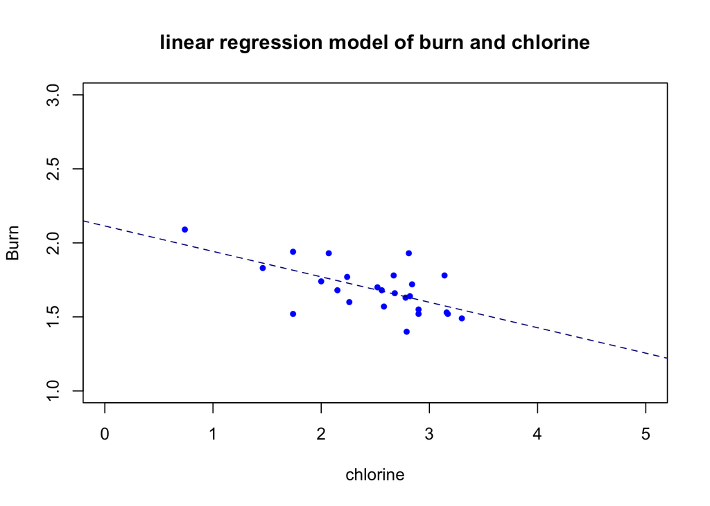

```r
plot(x = 0,
     xlab = "chlorine",
     ylab = "Burn",
     xlim = c(0, 5),
     ylim = c(1,3),
     main = "linear regression model of burn and chlorine")

points(x = tobacco$chlorine, y = tobacco$burn, col = "blue" , pch = 20)
abline(model_burn_chl, col="darkblue", lty=2)
```

## Question 1c

```r
sumSqMin <- function(par, data) {
  with(data, sum((par[1] + par[2] * y + par[3] * x - z)^2))
}


library(dplyr)

data <- tobacco %>%
  select(burn, chlorine)
data
```

```
##    burn chlorine
## 1  1.55     2.90
## 2  1.63     2.78
## 3  1.66     2.68
## 4  1.52     3.17
## 5  1.70     2.52
## 6  1.68     2.56
## 7  1.78     2.67
## 8  1.57     2.58
## 9  1.60     2.26
## 10 1.52     1.74
## 11 1.68     2.15
## 12 1.74     2.00
## 13 1.93     2.07
## 14 1.77     2.24
## 15 1.94     1.74
## 16 1.83     1.46
## 17 2.09     0.74
## 18 1.72     2.84
## 19 1.49     3.30
## 20 1.52     2.90
## 21 1.64     2.82
## 22 1.40     2.79
## 23 1.78     3.14
## 24 1.93     2.81
## 25 1.53     3.16
```

```r
min_residuals <- function(data, par) {
                   with(data, sum((par[1] + par[2] * burn - chlorine)^2))
}

#find coefficients of linear regression model
optim(par=c(0, 1), fn=min_residuals, data=data)
```

```
## $par
## [1]  6.299622 -2.262389
##
## $value
## [1] 5.385873
##
## $counts
## function gradient
##       85       NA
##
## $convergence
## [1] 0
##
## $message
## NULL
```

# Question 1d

```r
loglikelihood = function(beta,x,y){
  s <- beta[1]
  intercept <- beta[2]
  slope <- beta[3]
  fitted_values <- x*slope + intercept
  residual <- y - fitted_values

  n <- length(y)
  SSE <- sum(residual^2)
  ll = - 0.5*n*log(2*pi) - 0.5*n*log(s^2) - 0.5*1/(s^2)*SSE
  return(-ll)
}

fit <- optim(par=c(0.5,10,10), fn=loglikelihood, x = tobacco$chlorine, y = tobacco$burn, method="L-BFGS-B", lower=c(0.0001,-Inf,-Inf))
fit
```

```
## $par
## [1]  0.1279045  2.1141688 -0.1717861
##
## $value
## [1] -15.93874
##
## $counts
## function gradient
##       63       63
##
## $convergence
## [1] 0
##
## $message
## [1] "CONVERGENCE: REL_REDUCTION_OF_F <= FACTR*EPSMCH"
```

The loglikehood agrees with the above linear regression.

## Question 2

Using output from Part 1, fit a simple linear model using the most appropriate predictor. Take note of the correlation between the response variable and the fitted values of the regression. The square of this amount is known as the coefficient of determination (‘Multiple R-squared’ or simply 𝑅2). Explain what this quantity represents and why a larger 𝑅2 is preferred. Use the summary output and take note of the 𝑅2 amount. Comment on the significance of the beta parameters and whether regression analysis should be undertaken on this data.

```r
burn_chl <- lm(burn ~ chlorine, data = data)
summary(burn_chl)
```

```
##
## Call:
## lm(formula = burn ~ chlorine, data = data)
##
## Residuals:
##       Min        1Q    Median        3Q       Max
## -0.295267 -0.064830 -0.006598  0.093709  0.298555
##
## Coefficients:
##             Estimate Std. Error t value Pr(>|t|)
## (Intercept)  2.11419    0.11460  18.449 2.79e-15 ***
## chlorine    -0.17180    0.04493  -3.824  0.00087 ***
## ---
## Signif. codes:  0 '***' 0.001 '**' 0.01 '*' 0.05 '.' 0.1 ' ' 1
##
## Residual standard error: 0.1333 on 23 degrees of freedom
## Multiple R-squared:  0.3887, Adjusted R-squared:  0.3621
## F-statistic: 14.62 on 1 and 23 DF,  p-value: 0.00087
```

R^2 also known as coefficient of determination, R-squared is the proportion of the variation in dependent variable that can be explained by the independent variables. We want this to be large as we want our dependent variable to be explained by the independent variable as much as we can so we can define or determine the relationships between variables. In the case of the above model, it represents the proportion of variation of the response (burn) in relation to the chlorine.

A linear regression model was conducted to examine the dependent variable burn and the relationship with independent variable chlorine. We found a significant relationship (p < 0.001) between burn and chlorine (R2 = 0.3887). In this model the equattion for burn is burn = 2.11 + -(0.17*chlorine) ± 0.045. Because the p value is so low (p =0.00087), we can reject the null hypothesis and conclude that chlorine has a statistically significant effect on burn. With that being said, to improve the regression analysis we must include the other variables that may have relationship with burn included in the dataset.

# Question 2b

```r
# add magnes
burn_chl_mag <- lm(burn ~ chlorine + magnes , data = tobacco)
summary(burn_chl_mag)
```

```
##
## Call:
## lm(formula = burn ~ chlorine + magnes, data = tobacco)
##
## Residuals:
##      Min       1Q   Median       3Q      Max
## -0.21291 -0.08665 -0.02165  0.08332  0.28181
##
## Coefficients:
##             Estimate Std. Error t value Pr(>|t|)
## (Intercept)   2.4043     0.2208  10.890  2.5e-10 ***
## chlorine     -0.1639     0.0440  -3.724  0.00118 **
## magnes       -0.3213     0.2111  -1.522  0.14225
## ---
## Signif. codes:  0 '***' 0.001 '**' 0.01 '*' 0.05 '.' 0.1 ' ' 1
##
## Residual standard error: 0.1297 on 22 degrees of freedom
## Multiple R-squared:  0.4469, Adjusted R-squared:  0.3966
## F-statistic: 8.888 on 2 and 22 DF,  p-value: 0.001482
```

```r
#add phospho
burn_chl_mag_pho <- lm(burn ~ chlorine + magnes + phospho, data = tobacco)
summary(burn_chl_mag_pho)
```

```
##
## Call:
## lm(formula = burn ~ chlorine + magnes + phospho, data = tobacco)
##
## Residuals:
##      Min       1Q   Median       3Q      Max
## -0.19461 -0.08475 -0.01221  0.08982  0.24333
##
## Coefficients:
##             Estimate Std. Error t value Pr(>|t|)
## (Intercept)  2.81506    0.39900   7.055 5.81e-07 ***
## chlorine    -0.16733    0.04359  -3.839 0.000955 ***
## magnes      -0.30188    0.20927  -1.443 0.163900
## phospho     -0.86470    0.70308  -1.230 0.232344
## ---
## Signif. codes:  0 '***' 0.001 '**' 0.01 '*' 0.05 '.' 0.1 ' ' 1
##
## Residual standard error: 0.1282 on 21 degrees of freedom
## Multiple R-squared:  0.4841, Adjusted R-squared:  0.4104
## F-statistic: 6.568 on 3 and 21 DF,  p-value: 0.00264
```

```r
#add potas
burn_chl_mag_pho_pota <- lm(burn ~ chlorine + magnes + phospho + potas, data = tobacco)
summary(burn_chl_mag_pho_pota)
```

```
##
## Call:
## lm(formula = burn ~ chlorine + magnes + phospho + potas, data = tobacco)
##
## Residuals:
##      Min       1Q   Median       3Q      Max
## -0.19184 -0.07634 -0.02011  0.07045  0.27967
##
## Coefficients:
##             Estimate Std. Error t value Pr(>|t|)
## (Intercept)  1.78507    0.56467   3.161 0.004912 **
## chlorine    -0.16359    0.03949  -4.143 0.000504 ***
## magnes       0.03912    0.23777   0.165 0.870981
## phospho     -0.72604    0.63908  -1.136 0.269362
## potas        0.27909    0.11762   2.373 0.027789 *
## ---
## Signif. codes:  0 '***' 0.001 '**' 0.01 '*' 0.05 '.' 0.1 ' ' 1
##
## Residual standard error: 0.116 on 20 degrees of freedom
## Multiple R-squared:  0.5974, Adjusted R-squared:  0.5169
## F-statistic:  7.42 on 4 and 20 DF,  p-value: 0.00078
```

```r
#add calcuim
burn_chl_mag_pho_pota_others <- lm(burn ~ chlorine + magnes + phospho + potas+ calcium, data = tobacco)
summary(burn_chl_mag_pho_pota_others)
```

```
##
## Call:
## lm(formula = burn ~ chlorine + magnes + phospho + potas + calcium,
##     data = tobacco)
##
## Residuals:
##       Min        1Q    Median        3Q       Max
## -0.146238 -0.051623  0.000427  0.077924  0.141217
##
## Coefficients:
##             Estimate Std. Error t value Pr(>|t|)
## (Intercept)  1.29935    0.52869   2.458 0.023764 *
## chlorine    -0.17005    0.03474  -4.895 0.000101 ***
## magnes      -0.40455    0.26800  -1.510 0.147614
## phospho     -0.77267    0.56120  -1.377 0.184574
## potas        0.34640    0.10634   3.258 0.004142 **
## calcium      0.22317    0.08458   2.639 0.016190 *
## ---
## Signif. codes:  0 '***' 0.001 '**' 0.01 '*' 0.05 '.' 0.1 ' ' 1
##
## Residual standard error: 0.1019 on 19 degrees of freedom
## Multiple R-squared:  0.7054, Adjusted R-squared:  0.6278
## F-statistic: 9.098 on 5 and 19 DF,  p-value: 0.0001512
```

```r
# add nitrogen
burn_chl_mag_pho_pota_others <- lm(burn ~ chlorine + magnes + phospho + potas+ calcium+ nitrogen, data = tobacco)
summary(burn_chl_mag_pho_pota_others)
```

```
##
## Call:
## lm(formula = burn ~ chlorine + magnes + phospho + potas + calcium +
##     nitrogen, data = tobacco)
##
## Residuals:
##       Min        1Q    Median        3Q       Max
## -0.146329 -0.049841  0.003997  0.076611  0.144971
##
## Coefficients:
##             Estimate Std. Error t value Pr(>|t|)
## (Intercept)  1.35571    0.60301   2.248 0.037328 *
## chlorine    -0.16722    0.03803  -4.397 0.000347 ***
## magnes      -0.44679    0.33846  -1.320 0.203355
## phospho     -0.74313    0.59215  -1.255 0.225537
## potas        0.32131    0.16013   2.007 0.060061 .
## calcium      0.20809    0.11176   1.862 0.079029 .
## nitrogen     0.03395    0.15861   0.214 0.832898
## ---
## Signif. codes:  0 '***' 0.001 '**' 0.01 '*' 0.05 '.' 0.1 ' ' 1
##
## Residual standard error: 0.1045 on 18 degrees of freedom
## Multiple R-squared:  0.7061, Adjusted R-squared:  0.6082
## F-statistic: 7.208 on 6 and 18 DF,  p-value: 0.0004871
```

```r
# add nicotine
burn_chl_mag_pho_pota_others <- lm(burn ~ chlorine + magnes + phospho + potas+ calcium+  nitrogen + nicotine, data = tobacco)
summary(burn_chl_mag_pho_pota_others)
```

```
##
## Call:
## lm(formula = burn ~ chlorine + magnes + phospho + potas + calcium +
##     nitrogen + nicotine, data = tobacco)
##
## Residuals:
##       Min        1Q    Median        3Q       Max
## -0.152407 -0.045178  0.005471  0.047113  0.142490
##
## Coefficients:
##             Estimate Std. Error t value Pr(>|t|)
## (Intercept)  1.49481    0.62039   2.409  0.02759 *
## chlorine    -0.14132    0.04641  -3.045  0.00731 **
## magnes      -0.63033    0.38756  -1.626  0.12225
## phospho     -0.66708    0.59802  -1.115  0.28016
## potas        0.30001    0.16182   1.854  0.08118 .
## calcium      0.17839    0.11597   1.538  0.14240
## nitrogen    -0.01406    0.16626  -0.085  0.93360
## nicotine     0.09009    0.09228   0.976  0.34263
## ---
## Signif. codes:  0 '***' 0.001 '**' 0.01 '*' 0.05 '.' 0.1 ' ' 1
##
## Residual standard error: 0.1046 on 17 degrees of freedom
## Multiple R-squared:  0.7217, Adjusted R-squared:  0.6071
## F-statistic: 6.299 on 7 and 17 DF,  p-value: 0.0009357
```

```r
#add sugar == FULL MODEL
full_model <- lm(burn ~ chlorine + magnes + phospho + potas+ calcium+  nitrogen + nicotine + sugar, data = tobacco)
summary(burn_chl_mag_pho_pota_others)
```

```
##
## Call:
## lm(formula = burn ~ chlorine + magnes + phospho + potas + calcium +
##     nitrogen + nicotine, data = tobacco)
##
## Residuals:
##       Min        1Q    Median        3Q       Max
## -0.152407 -0.045178  0.005471  0.047113  0.142490
##
## Coefficients:
##             Estimate Std. Error t value Pr(>|t|)
## (Intercept)  1.49481    0.62039   2.409  0.02759 *
## chlorine    -0.14132    0.04641  -3.045  0.00731 **
## magnes      -0.63033    0.38756  -1.626  0.12225
## phospho     -0.66708    0.59802  -1.115  0.28016
## potas        0.30001    0.16182   1.854  0.08118 .
## calcium      0.17839    0.11597   1.538  0.14240
## nitrogen    -0.01406    0.16626  -0.085  0.93360
## nicotine     0.09009    0.09228   0.976  0.34263
## ---
## Signif. codes:  0 '***' 0.001 '**' 0.01 '*' 0.05 '.' 0.1 ' ' 1
##
## Residual standard error: 0.1046 on 17 degrees of freedom
## Multiple R-squared:  0.7217, Adjusted R-squared:  0.6071
## F-statistic: 6.299 on 7 and 17 DF,  p-value: 0.0009357
```

# Question 2c

With that being said, A linear model without sugar and nitrogen is what we will go with due to the small beta coefficents and high p-values suggesting they do not have a relationship with the burn time.

# Question 2d

```r
model <- lm(burn ~ chlorine + magnes + phospho + potas+ calcium + nicotine, data = tobacco)
summary(model)
```

```
##
## Call:
## lm(formula = burn ~ chlorine + magnes + phospho + potas + calcium +
##     nicotine, data = tobacco)
##
## Residuals:
##       Min        1Q    Median        3Q       Max
## -0.154107 -0.046705  0.003748  0.047389  0.143929
##
## Coefficients:
##             Estimate Std. Error t value Pr(>|t|)
## (Intercept)  1.51254    0.56754   2.665  0.01578 *
## chlorine    -0.14092    0.04486  -3.141  0.00565 **
## magnes      -0.64159    0.35380  -1.813  0.08647 .
## phospho     -0.65787    0.57156  -1.151  0.26479
## potas        0.29107    0.11914   2.443  0.02510 *
## calcium      0.17345    0.09741   1.781  0.09186 .
## nicotine     0.08778    0.08569   1.024  0.31919
## ---
## Signif. codes:  0 '***' 0.001 '**' 0.01 '*' 0.05 '.' 0.1 ' ' 1
##
## Residual standard error: 0.1017 on 18 degrees of freedom
## Multiple R-squared:  0.7216, Adjusted R-squared:  0.6288
## F-statistic: 7.776 on 6 and 18 DF,  p-value: 0.0003106
```

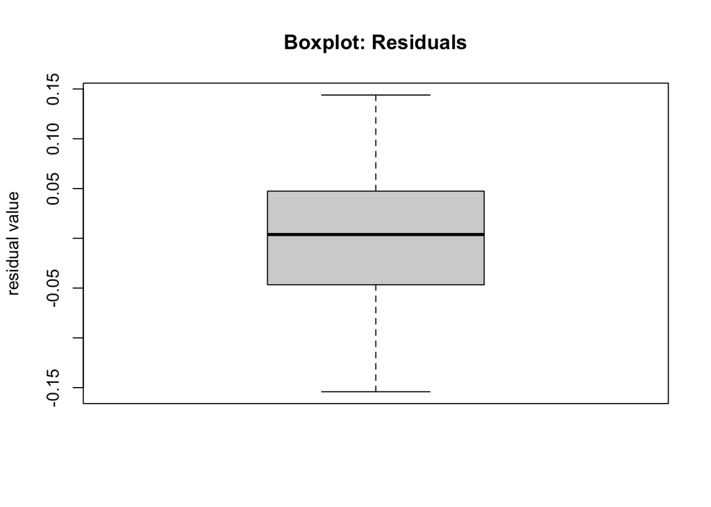

```r
boxplot(model[['residuals']],main='Boxplot: Residuals',ylab='residual value')
```

```r
confint(model)
```

```
##                   2.5 %      97.5 %
## (Intercept)  0.32019458  2.70488902
## chlorine    -0.23517304 -0.04665889
## magnes      -1.38489300  0.10171270
## phospho     -1.85867266  0.54293766
## potas        0.04076141  0.54138577
## calcium     -0.03120371  0.37811153
## nicotine    -0.09223777  0.26780012
```

## Checking Assumptions

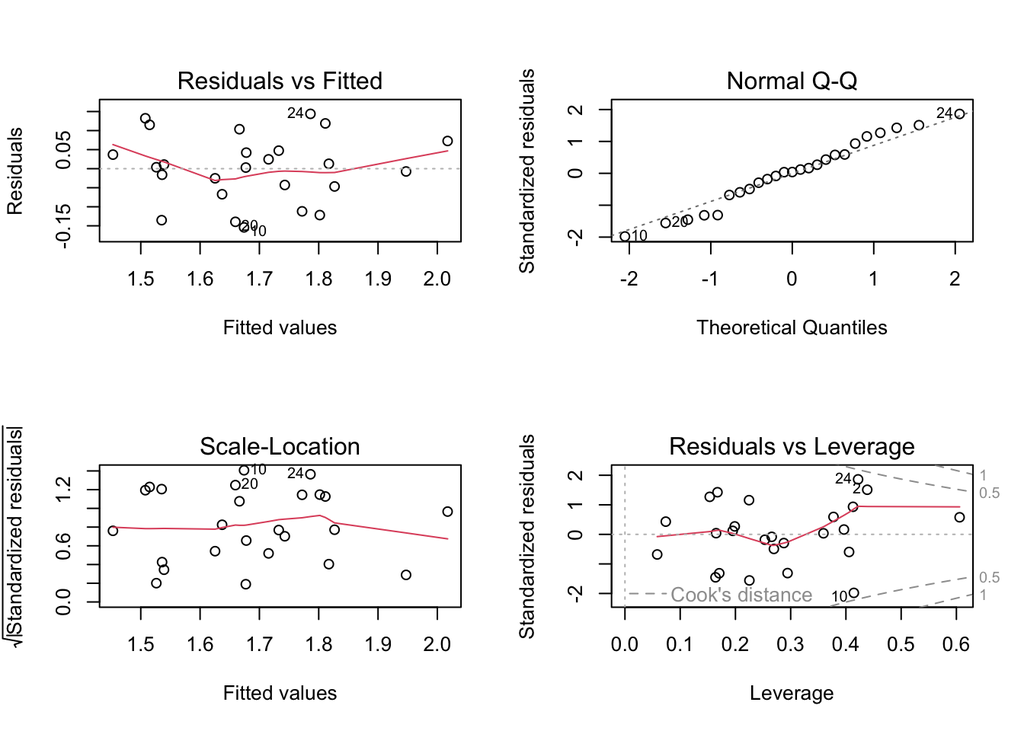

```r
par(mfrow = c(2, 2))
plot(model)
```

# Linearity

Linearity: In plot 1,1, there is no pattern in the residual plot and it is more or less centred around mean 0. This suggests that we can assume linear relationship between the predictors and the response variable.

# Homogenity

The scale-location plot shows the residuals are spread equally along the ranges of predictors as it is a horizontal line with equally spread points. This suggests constant variances in residual errors or homogenity.

# Normality of residuals

The normal probability plot of residuals approximates a straight line thus agreeing with the normality of residuals.

# Outliers

```r
# This package runs the shapiro and the Wilcox test for testing the assumptions
gvlma(model)
```

```
##
## Call:
## lm(formula = burn ~ chlorine + magnes + phospho + potas + calcium +
##     nicotine, data = tobacco)
##
## Coefficients:
## (Intercept)     chlorine       magnes      phospho        potas      calcium
##     1.51254     -0.14092     -0.64159     -0.65787      0.29107      0.17345
##    nicotine
##     0.08778
##
##
## ASSESSMENT OF THE LINEAR MODEL ASSUMPTIONS
## USING THE GLOBAL TEST ON 4 DEGREES-OF-FREEDOM:
## Level of Significance =  0.05
##
## Call:
##  gvlma(x = model)
##
##                      Value p-value                Decision
## Global Stat        3.79614  0.4343 Assumptions acceptable.
## Skewness           0.08667  0.7685 Assumptions acceptable.
## Kurtosis           0.79845  0.3716 Assumptions acceptable.
## Link Function      2.23743  0.1347 Assumptions acceptable.
## Heteroscedasticity 0.67358  0.4118 Assumptions acceptable.
```

# Question 3

```r
days <- c(0, 8, 2, 41, 63, 79, 97, 117, 135, 154)
beetles <- c(2, 47, 192, 256, 768, 896, 1120, 896, 1184, 1024)


logistic <- function(N0, r, K, d, b) {
  b - K*N0 / (N0 + (K - N0)*exp(-r*d))
}

sse <- function(params, d, b) {
  err <- logistic(params[1], params[2], params[3], d, b)
  sum(err^2)
}

fit<- nlm(sse, c(N0=2, r=1, K=1), d=days, b=beetles, hessian = TRUE)
fit
```

```
## $minimum
## [1] 85729.69
##
## $estimate
## [1] 1.834905e+01 7.644501e-02 1.062432e+03
##
## $gradient
## [1] -3.172244e-06 -3.623427e-03 -1.369679e-07
##
## $hessian
##             [,1]         [,2]         [,3]
## [1,]    729.2936    738705.67    27.648098
## [2,] 738705.6681 782217835.90 36560.961491
## [3,]     27.6481     36560.96     9.315149
##
## $code
## [1] 1
##
## $iterations
## [1] 31
```